# part1

Simon

28 11 2017

```r
# load data
load(url('https://github.com/systats/workshop_data_science/raw/master/Rnotebook/data/ess_workshop.Rdata'))
# filter data

library(dplyr)
ess_ger <- ess %>%
  filter(country == "DE")
```

```r
fit_null <- ess_ger %>%
  lm(imm_econ ~ 1, data = .)
fit_1 <- ess_ger %>%
  lm(imm_econ ~ edu, data = .)
fit_2 <- ess_ger %>%
  lm(imm_econ ~ edu + income, data = .)
ess_ger %>%
  lm(imm_econ ~ edu + income + age + I(age^2), data = .) %>%
  broom::tidy()
```

```
##          term      estimate    std.error statistic      p.value
## 1 (Intercept)  5.9349814831 0.3082548254 19.253491 3.759595e-77
## 2         edu  0.1915797340 0.0227268945  8.429649 5.763811e-17
## 3      income  0.0741948714 0.0175057650  4.238311 2.333559e-05
## 4         age -0.0702992536 0.0136998941 -5.131372 3.096792e-07
## 5    I(age^2)  0.0006791562 0.0001380618  4.919217 9.252048e-07
```

```r
library(GGally)
```

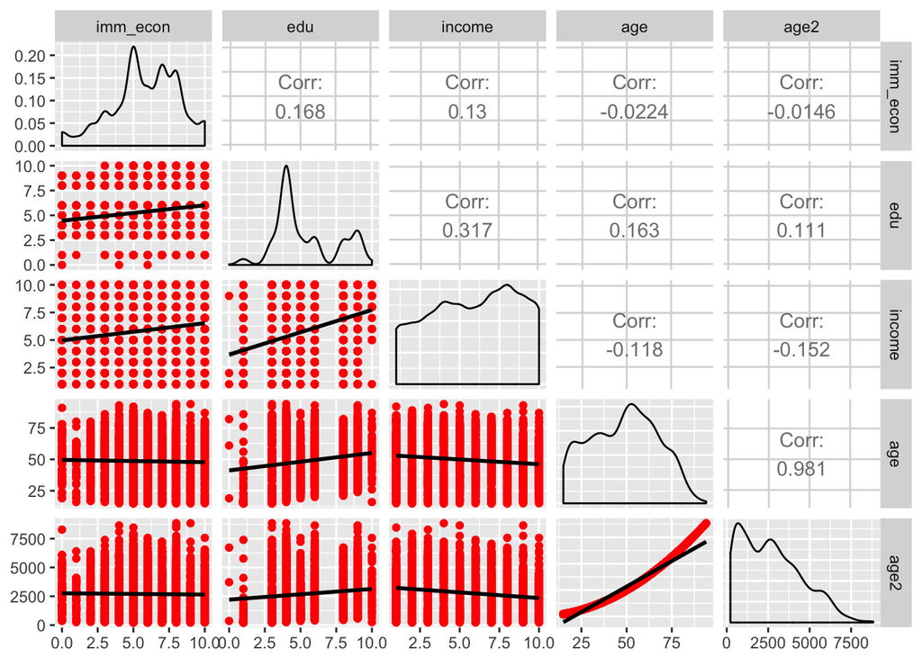

```r
ess_ger %>%
  mutate(age2 = age^2) %>%
  select(imm_econ, edu, income, age, age2) %>%
  GGally::ggpairs(lower = list(continuous = wrap("smooth", method = "lm", color = "red")))
```

Ihrem Profil konnte wir entnehmen, dass Sie die Statistiksoftware R benutzen. Gemeinsam mit Kommilitonen der Universität Stuttgart haben wir die “R User Group Stuttgart” gegründet, um die vielen R User in Stuttgart zu vernetzen.

Gerne würden wir Sie daher in unserere XING Gruppe einladen um miteinander in Kontakt zu treten. Wir würden uns freuen Sie schon bald als ein neues Gruppen-Mitglied begrüßen zu können!

Die Gruppe finden Sie hier: https://www.xing.com/communities/groups/r-user-group-stuttgart-664e-1101184

Auf Facebook sind wir auch vertreten: https://www.facebook.com/groups/rstuttgart/

Die R User Group Stuttgart trifft sich immer Donnerstag (während des Semesters) von 17:30 bis 19:00 im CIP Pool der Breitscheidstraße 2 an der Universität Stuttgart (M2.5.005).

Viele Grüße

Simon Roth und Fabio Votta

Um persönlich Kontakt aufzunehmen, adden Sie uns doch einfach: https://www.xing.com/profile/Simon_Roth21?sc_o=mxb_p https://www.xing.com/profile/Fabio_Votta2?sc_o=da980_e

### Good version

deinem Profil konnte wir entnehmen, dass du die Statistiksoftware R benutzt. Gemeinsam mit Kommilitonen der Universität Stuttgart haben wir die “R User Group Stuttgart” gegründet, um die vielen R User in Stuttgart zu vernetzen.

Gerne würden wir dich daher in unsere XING Gruppe einladen um miteinander in Kontakt zu treten. Wir würden uns freuen dich schon bald als ein neues Gruppen-Mitglied begrüßen zu können!

Die Gruppe findest du hier: https://www.xing.com/communities/groups/r-user-group-stuttgart-664e-1101184

Auf Facebook sind wir auch vertreten: https://www.facebook.com/groups/rstuttgart/

Die R User Group Stuttgart trifft sich immer Donnerstag (während des Semesters) von 17:30 bis 19:00 im CIP Pool der Breitscheidstraße 2 an der Universität Stuttgart (M2.5.005).

Viele Grüße

Simon Roth und Fabio Votta

Um persönlich Kontakt aufzunehmen, add uns doch einfach: https://www.xing.com/profile/Simon_Roth21?sc_o=mxb_p https://www.xing.com/profile/Fabio_Votta2?sc_o=da980_e